# R Notebook

Re-run models as SEM?

Start with site-level predictors of biomass and variance in biomass

- Precipitation deficit (PET - PTo?) or function of MAP + MAT
- Soil resources (N, P, K, C, pH)
- Disturbance + management
- Invasion history?

Use these to predict site-level biomass, then also estimate variance in productivity by variance in these site-level predictors? How to best link soil resources to biomass?

- Then, link between these other drivers, biomass, and distribution of diversity within each site?

Plot partial correlations between resource heterogeneity + supply on turnover / diversity?

## Follow with plot of diversity partitioning as a function of difference in light interception

Is beta-diversity driven by changes in nestedness within each sites (species packing?) or turnover (different affinities to competitive environment / soil conditions)

## Variable definitions

### Spatial Dataset

- biomass ~ precipitation (MAT / MAT / PET - PTo) + mean soil resource supply + other factors
- spatial heterogeneity in productivity ~ some function of within-site soil resource heterogeniety + other factors
- total species pool ~ function of both biomass, heterogeneity, and other factors
- Representation in an individual plot ~ function of total species pool biomass, heterogeneity, and other factors

### Creating spatial dataset

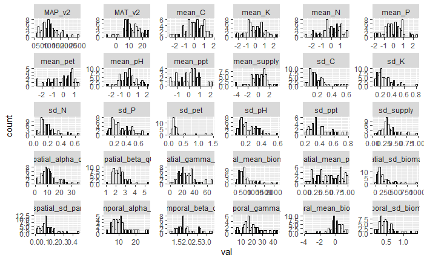

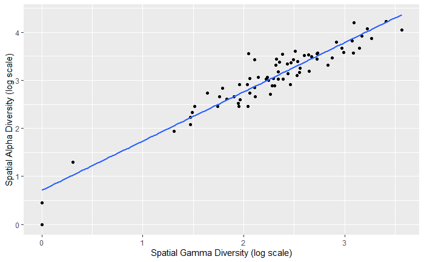

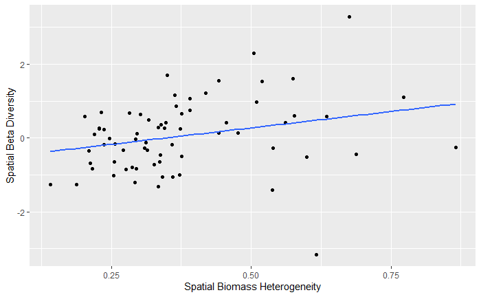

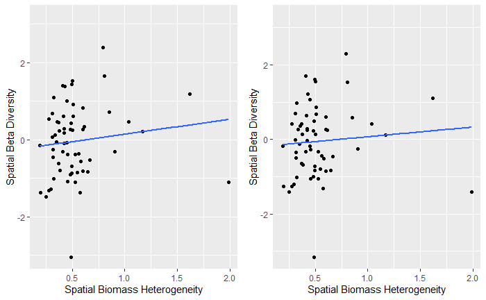

| site_code | spatial_beta_q0 | spatial_alpha_q0 | spatial_gamma_q0 | elevation | managed | burned | grazed | anthropogenic | latitude | MAP_v2 | MAT_v2 | ann_frac | mean_N | mean_C | mean_P | mean_K | mean_pH | sd_N | sd_C | sd_P | sd_K | sd_pH | mean_supply | sd_supply | sd_ppt | sd_pet | mean_ppt | mean_pet | spatial_mean_biomass | … |
| --- | --- | --- | --- | --- | --- | --- | --- | --- | --- | --- | --- | --- | --- | --- | --- | --- | --- | --- | --- | --- | --- | --- | --- | --- | --- | --- | --- | --- | --- | --- |
| amcamp.us | 1.913246 | 12.833333 | 23.666667 | 41.000 | 0 | 0 | 0 | 0 | 48.4650406 | 580 | 10.0000000 | 0.3080045850 | 0.79542218 | 0.82479519 | 0.77331967 | -0.26454768 | -0.55265038 | 0.31589671 | 0.27429086 | 0.47369508 | 0.2883465 | 0.11665632 | 1.119659903 | 0.45679452 | NA | NA | NA | NA | 736.74636 | … |
| arch.us | 2.479769 | 14.033333 | 34.000000 | 8.200 | 1 | 1 | 1 | 0 | 27.1500000 | 1205 | 22.7333333 | 0.0071130354 | -0.47788899 | 0.06244166 | -0.57645121 | -1.48819577 | -2.34470462 | 0.21517248 | 0.22067947 | 0.18692904 | 0.3369099 | 0.19444330 | -1.204201439 | 0.37842593 | 0.2941283 | 0.11375748 | 0.98510464 | 1.09103873 | 342.20000 | … |
| azi.cn | 1.634812 | 35.300000 | 57.000000 | 3500.000 | 0 | 0 | 0 | 0 | 33.6700000 | 711 | 1.3625000 | 0.0075379798 | 0.93466359 | 0.71561988 | 0.93533476 | 0.66454001 | -0.23958802 | 0.12987070 | 0.13568534 | 0.13853023 | 0.2145270 | 0.14598352 | 1.683182029 | 0.16498554 | NA | NA | NA | NA | 451.14533 | … |
| badlau.de | 2.161383 | 9.916667 | 21.000000 | 120.000 | 1 | 0 | 0 | 1 | 51.3921380 | 523 | 9.3291667 | 0.2540675845 | -0.06077550 | 0.28699442 | 0.47009878 | 0.24926803 | 0.99000440 | 0.16757318 | 0.14384252 | 0.11586553 | 0.1115458 | 0.11116038 | 0.525916039 | 0.12392056 | 0.3411483 | 0.13512523 | -0.43020162 | -0.60825343 | 767.78083 | … |
| bari.ar | 2.651884 | 7.066667 | 18.333333 | 786.000 | 0 | 0 | 0 | 0 | -41.0064400 | 787 | 8.7875001 | 0.1738475444 | -0.49774439 | -0.23095766 | 0.63347812 | 0.36288848 | 0.32345794 | 0.35838529 | 0.25691995 | 0.31107179 | 0.2182109 | 0.13487124 | 0.191749869 | 0.44294935 | NA | NA | NA | NA | 470.34707 | … |
| barta.us | 2.520085 | 11.800000 | 29.000000 | 767.000 | 0 | 0 | 0 | 0 | 42.2445860 | 581 | 9.0666666 | 0.0568119140 | -1.14000604 | -1.16022441 | -0.61033575 | -0.65532294 | -0.08630543 | 0.25771224 | 0.24667808 | 0.17306401 | 0.1128863 | 0.16879492 | -1.743783937 | 0.34634152 | NA | NA | NA | NA | 460.55667 | … |
| bldr.us | 1.607492 | 9.600000 | 15.000000 | 1633.000 | 1 | 0 | 0 | 0 | 39.9720220 | 487 | 9.9041666 | 0.2151111111 | -0.59676965 | -0.52261317 | -0.67028041 | -0.64889291 | 0.71993253 | 0.19777515 | 0.17407092 | 0.18321256 | 0.1614027 | 0.30965307 | -1.183541375 | 0.30415237 | 0.6536961 | 0.14818781 | -0.59200826 | 0.62083423 | 363.67500 | … |
| bnch.us | 2.191836 | 9.433333 | 20.000000 | 1318.083 | 0 | 0 | 0 | 0 | 44.2766854 | 1618 | 6.7708333 | 0.0414530046 | 1.03923997 | 1.00533755 | -0.86340752 | -0.66288090 | -0.56828986 | 0.18042568 | 0.15758566 | 0.16034171 | 0.2980606 | 0.14517685 | 0.284960930 | 0.31924563 | 0.2356729 | 0.18542062 | 1.77834186 | -0.14625169 | 239.87000 | … |
| bogong.au | 1.659413 | 17.066667 | 27.666667 | 1760.000 | 0 | 0 | 0 | 0 | -36.8740000 | 1678 | 5.9833333 | 0.0042675882 | 0.97469477 | 0.98085118 | 0.42777335 | 0.18182824 | -1.92683063 | 0.23157853 | 0.23111102 | 0.22957530 | 0.1806606 | 0.12750058 | 1.331212360 | 0.29699742 | 0.4275674 | 0.24885888 | 0.93376669 | -1.34863519 | 479.71333 | … |
| bttr.us | 2.690596 | 13.433333 | 33.666667 | 1500.000 | 0 | 0 | 0 | 0 | 44.2795180 | 1623 | 6.4999999 | 0.0268063634 | 1.45003952 | 1.24981117 | -0.42525516 | -0.54754690 | -0.54665988 | 0.18139035 | 0.16103630 | 0.45704986 | 0.4190803 | 0.35328619 | 0.895527093 | 0.31308044 | NA | NA | NA | NA | 417.22500 | … |

[output cut: 62 more lines]

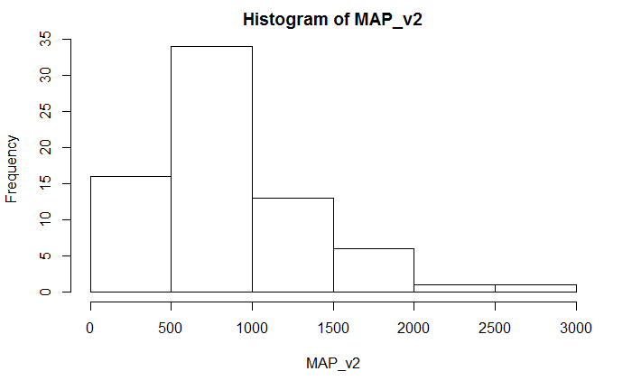

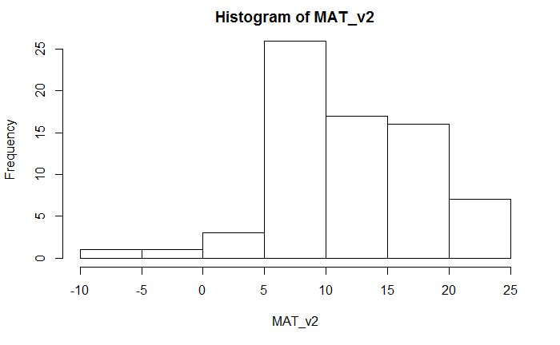

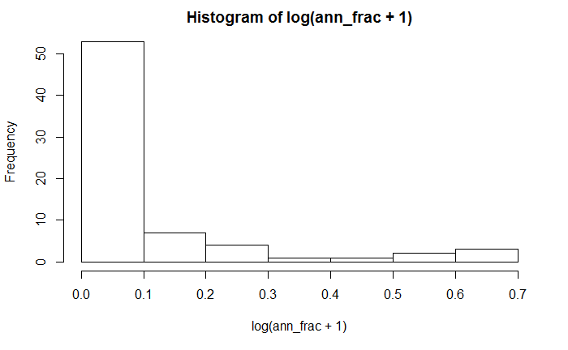

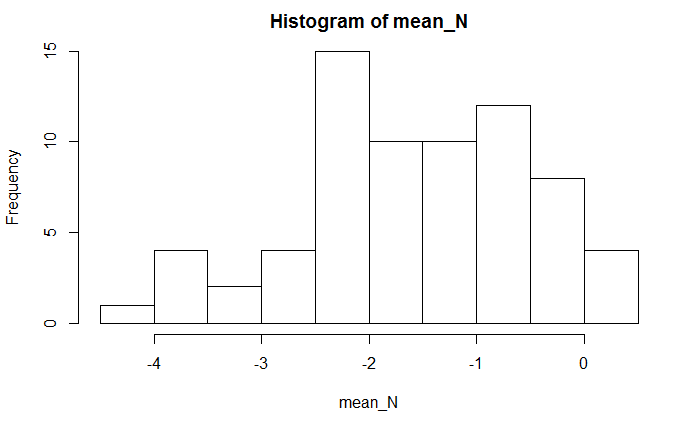

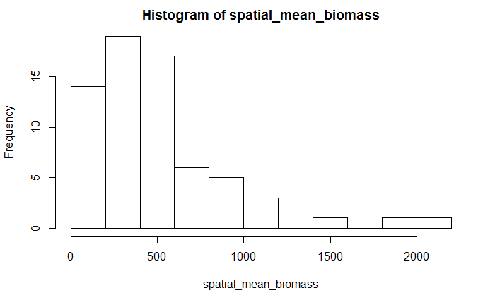

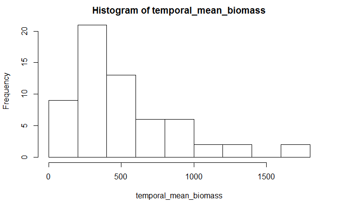

```
Call:
lm(formula = log(spatial_table$spatial_gamma_q0) ~ spatial_table$spatial_mean_biomass +
    spatial_table$spatial_cv_par)

Residuals:
     Min       1Q   Median       3Q      Max
-1.84865 -0.31120 -0.00342  0.35363  1.00262

Coefficients:
                                     Estimate Std. Error t value Pr(>|t|)
(Intercept)                         3.3821839  0.1882149  17.970   <2e-16 ***
spatial_table$spatial_mean_biomass -0.0002329  0.0002043  -1.140    0.259
spatial_table$spatial_cv_par       -0.2388654  0.3064983  -0.779    0.439
---
Signif. codes:  0 ‘***’ 0.001 ‘**’ 0.01 ‘*’ 0.05 ‘.’ 0.1 ‘ ’ 1

Residual standard error: 0.5571 on 56 degrees of freedom
  (13 observations deleted due to missingness)
Multiple R-squared:  0.02416,   Adjusted R-squared:  -0.0107
F-statistic: 0.6931 on 2 and 56 DF,  p-value: 0.5043
```

```
lavaan 0.6-5 ended normally after 101 iterations

  Estimator                                         ML
  Optimization method                           NLMINB
  Number of free parameters                         34

                                                  Used       Total
  Number of observations                            57          72

Model Test User Model:

  Test statistic                                56.337
  Degrees of freedom                                31
  P-value (Chi-square)                           0.004

Parameter Estimates:

  Information                                 Expected
  Information saturated (h1) model          Structured
  Standard errors                             Standard

Latent Variables:
                       Estimate  Std.Err  z-value  P(>|z|)
  SoilHeterogeneity =~
    var_ph                1.000
    var_N                 0.980    0.497    1.974    0.048
    var_P                 2.880    1.170    2.461    0.014
    var_K                 1.932    0.766    2.523    0.012

Regressions:
                   Estimate  Std.Err  z-value  P(>|z|)
  SpatialHet ~
    SoilHeterognty    1.365    0.704    1.937    0.053
    Grazing           0.029    0.061    0.485    0.628
    AnthroDistrbnc   -0.060    0.055   -1.100    0.272
  light_sd ~
    SpatialHet        0.184    0.057    3.220    0.001
  SiteRich ~
    SpatialHet       -0.730    0.406   -1.798    0.072
    Grazing          -0.109    0.197   -0.553    0.580
```

[output cut: 22 more lines]

```
    SoilHeterognty    0.000

Variances:
                   Estimate  Std.Err  z-value  P(>|z|)
   .var_ph            0.011    0.002    5.057    0.000
   .var_N             0.012    0.002    5.087    0.000
   .var_P             0.006    0.004    1.367    0.172
   .var_K             0.011    0.003    3.809    0.000
   .SpatialHet        0.024    0.005    5.106    0.000
   .light_sd          0.005    0.001    5.339    0.000
   .SiteRich          0.264    0.050    5.339    0.000
   .SiteBeta          0.055    0.010    5.339    0.000
    SoilHeterognty    0.002    0.001    1.362    0.173
    Grazing           0.145    0.027    5.339    0.000
    AnthroDistrbnc    0.176    0.033    5.339    0.000
```